# Implementations of Optimisation Algorithms in R with Applications to the Rosenbrock Function

*We refer to Amir Beck’s “Introduction to Nonlinear Optimization - Theory, Algorithms and Applications”*

We demonstrate implementations of different optimisation algorithms, namely: - Gradient Method - Pure Newton Method - BFGS

We benchmark each algorithm’s performance on the Rosenbrock function, notorious in numerical optimisation for being very difficult to minimise algorithmically.

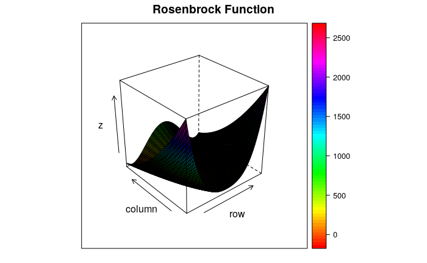

## Gradient Method

*Based on Beck, example 4.6, p.54*

Implementation of the **Gradient Method**, or **Gradient Descent**. We iterate methods on
$$\mathbf{x_{k+1} = x_k } + t_k \mathbf{d}_k \hspace{40 pt} k = 0, 1, 2, ...$$

where the descent direction $\mathbf{d}_k$ is the negative gradient $- \nabla f(\mathbf{x}_k)$, and the stepsize $t_k$ is chosen with backtracking. To do this, we require the first derivative of the Rosenbrock function.

```r
f1 <- deriv(expression((a-x)^2 + b*(y-x^2)^2), namevec = c('x', 'y'), function.arg=T, hessian=F) #calculate gradient

GradDesc <- function(f,f1,x0, s=1, alpha = 1/4, beta = 1/2, eps = 1e-2, max_iter = 1000){
  x <- x0 #set initial coordinate
  iter <- 0 #set iterations to 0
  grad <-  attr(f1(x[1], x[2]), "gradient") #compute gradient at current coordinate
  fun_val <- rep(0, max_iter) #initiate vector of function values
  coords <- matrix(NA, nrow =  max_iter, ncol = 2) #initiate vector of coordinates


  while (norm(grad, type ="2") > eps && iter < max_iter){
    iter <- iter + 1 #increment iterations
    t <- s #set t to initial stepsize
    change <- x - t* grad #set change in coords

    while (f(x[1],x[2]) - f(change[1],change[2]) < alpha * t * norm(grad, type ="2")^2) {
       t <- beta * t  #set stepsize by backtracking
       change <- x - t* grad #set change in coords
    }

    x <- x-t*grad #move coords
    grad <-  attr(f1(x[1], x[2]), "gradient") #compute gradient at current coordinate
    fun_val[iter] <- f(x[1], x[2]) #compute value of function at current coordinate
    #print(fun_val[iter])
    coords[iter,] <- t(x) #store coordinates
  }

  c(Iterations = iter, #print step
    Coordinates = coords[iter,], #print optima coordinates
    Gradient = grad, #print gradient
    Value = fun_val[iter]) # print fn val
}
```

Run for the Rosenbrock function, starting at the origin

```r
GradDesc(f, f1, x0 = c(0,0), eps = 1e-2)
```

```
   Iterations  Coordinates1  Coordinates2     Gradient1     Gradient2         Value
 1.000000e+03  9.291768e-01  8.632091e-01 -8.200959e-02 -3.209120e-02  5.018499e-03
```

## Newton Method

*Based on Beck, p.86*

Let’s try this for a quadratic f

```r
#Set initial quadratic fn
A <- diag(2,2,2)
b <- c(1,1)
c <- 5
x0 <- c(1000,-20000)
PNM(fn,grad,hessian,x0,0.001) #solve
```

[output not shown]

It so happens that the Newton Method solves any quadratic optimum in one step. Let’s try for a more complicated f

```r
fn <- function(x){x^5 + 6*x^3 - 2*x + 1 } #set f as 1d, 5th order polynomial
grad <- function(x){ 5*x^4 + 18*x^2 -2} #obtain gradient
hessian <- function(x){ 20*x^3 + 36*x} #find hessian
x0 <- -20
PNM(fn,grad,hessian,x0,0.001) #solve
```

[output not shown]